# Phase 4 — Inter-Individual Variability (IIV)

Adding random effects on CL, V, and Ka

Author

Pramod BR

Published

June 28, 2026

## 1 Objectives

The base model (Phase 3) allowed only **clearance** to vary between subjects. Here we add **between-subject random effects** on **V** and **Ka** as well, so each subject has their own clearance, volume, *and* absorption rate. We then test whether the extra variability is justified — better fit, well-estimated, and plausibly distributed.

## 2 What a random effect is

For each parameter we write, e.g., `cl = exp(tcl + eta.cl)`, where `eta.cl` is a subject-specific deviation drawn from a normal distribution `N(0, omega^2)`. The population shares one typical curve; each subject’s curve is a shifted version of it. The spread of those shifts — the IIV — is summarised as a **CV%**.

The fitted model’s structure is shown as equations in the next section.

## 3 Fit the IIV model

```r
dat      <- build_nonmem_data()
base_fit <- readRDS(fs::path(PATH_MODELS, "base_fit.rds"))
iiv_fit  <- fit_iiv_model(dat)
```

$$\begin{align*}
{ka} & = \exp\left({tka}+{eta.ka}\right) \\
{cl} & = \exp\left({tcl}+{eta.cl}\right) \\
{v} & = \exp\left({tv}+{eta.v}\right) \\
\frac{d \: depot}{dt} & = -{ka} {\times} {depot} \\
\frac{d \: center}{dt} & = {ka} {\times} {depot}-\left(\frac{{cl}}{{v}}\right) {\times} {center} \\
{cp} & = \frac{{center}}{{v}} \\
{cp} & \sim add({add.sd})+prop({prop.sd})
\end{align*}$$

## 4 Parameter estimates

```r
base_param_table(iiv_fit) |>
  kbl(caption = "IIV model estimates (fixed effects, IIV CV%, and shrinkage)",
      digits = 3) |>
  kable_styling(bootstrap_options = c("striped", "hover", "condensed"),
                full_width = FALSE)
```

IIV model estimates (fixed effects, IIV CV%, and shrinkage)

| Parameter | Est. | SE | %RSE | Back-transformed(95%CI) | BSV(CV%) | Shrink(SD)% |
| --- | --- | --- | --- | --- | --- | --- |
| tka | 0.389 | 0.198 | 50.9 | 1.48 (1, 2.17) | 68.8 | 1.88%< |
| tcl | 1.03 | 0.074 | 7.22 | 2.79 (2.41, 3.22) | 25.7 | 1.12%< |
| tv | 3.47 | 0.046 | 1.33 | 32 (29.3, 35) | 12.6 | 15.7%< |
| add.sd | 0.261 |  |  | 0.261 |  |  |
| prop.sd | 0.136 |  |  | 0.136 |  |  |

Read the **BSV(CV%)** column for the size of each random effect and the **Shrink(SD)%** column for how well the data support it. As a rule of thumb, shrinkage under ~30% means the individual estimates are genuinely informed by the data rather than collapsing to the population mean.

## 5 Is the added variability justified?

We compare the base and IIV models by objective function value (**OFV**), and by **AIC/BIC**, which penalise extra parameters. By the likelihood-ratio test, adding two random effects (V and Ka) is significant at p < 0.05 if the OFV drops by more than **5.99** (χ², 2 df).

```r
cmp <- compare_models(
  model_metrics(base_fit, "Base (IIV on CL)"),
  model_metrics(iiv_fit,  "IIV on CL, V, Ka")
)
cmp |>
  kbl(caption = "Base vs IIV model comparison", digits = 2) |>
  kable_styling(bootstrap_options = c("striped", "hover", "condensed"),
                full_width = FALSE)
```

Base vs IIV model comparison

| Model | OFV | AIC | BIC | nPar | dOFV | dAIC |
| --- | --- | --- | --- | --- | --- | --- |
| Base (IIV on CL) | 177.81 | 432.41 | 449.70 | 6 | 0.00 | 0.00 |
| IIV on CL, V, Ka | 104.36 | 362.96 | 386.02 | 8 | -73.45 | -69.45 |

The IIV model lowers the OFV by **73.45** points relative to base (ΔAIC = -69.45). A drop well beyond the 5.99 threshold means the between-subject variability on V and Ka is **statistically warranted** — the model genuinely fits better, not just by added flexibility.

## 6 Random-effect distributions

The empirical-Bayes η estimates should be centred on 0 and roughly symmetric — the model’s normality assumption.

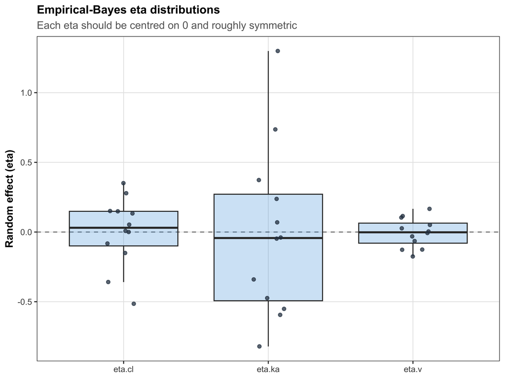

Eta distributions for CL, V, and Ka (centred on zero = assumption met).

```r
iiv_plot_eta(iiv_fit)
```

## 7 Key takeaways

- Random effects on **V and Ka** were added to the base (CL-only) model.
- The OFV fell by **73.45** (≫ the 5.99 cut-off for 2 df), so the extra IIV is **justified**.
- Shrinkage and the η distributions indicate the random effects are data-supported, not artefacts.
- This full-IIV model is now the reference onto which we test a **covariate** (body weight) next.

> Next: **Phase 5 — Covariate model**, testing whether body weight explains part of the between-subject variability in CL and V. ```